# Homework 2

Ben Rodwell

February 23, 2019

# QUESTION 1: Every Saturday, at the same time, a primatologist goes and sits in the forest in the morning and listens for titi monkey calls, counting the number of calls they hear in a 2 hour window from 5am to 7am. Based on previous knowledge, she believes that the mean number calls she will hear in that time is 15. Let X represent the appropriate Poisson random variable of the number of calls heard in each monitoring session.

## 1.a. What is the probability that she will hear more than 8 calls during any given session?

```r
ppois(q = 8, lambda = 15, lower.tail = FALSE)
```

```
## [1] 0.9625535
```

## 1.b. What is the probability that she will hear no calls in a session?

```r
ppois(q = 0, lambda = 15, lower.tail = T)
```

```
## [1] 3.059023e-07
```

```r
dpois(x = 0, lambda = 15)
```

```
## [1] 3.059023e-07
```

## 1.c. What is the probability that she will hear exactly 3 calls in a session?

```r
dpois(x = 3, lambda = 15)
```

```
## [1] 0.0001720701
```

## 1.d. Plot the relevant Poisson mass function over the values in range 0 ≤ x ≤ 30.

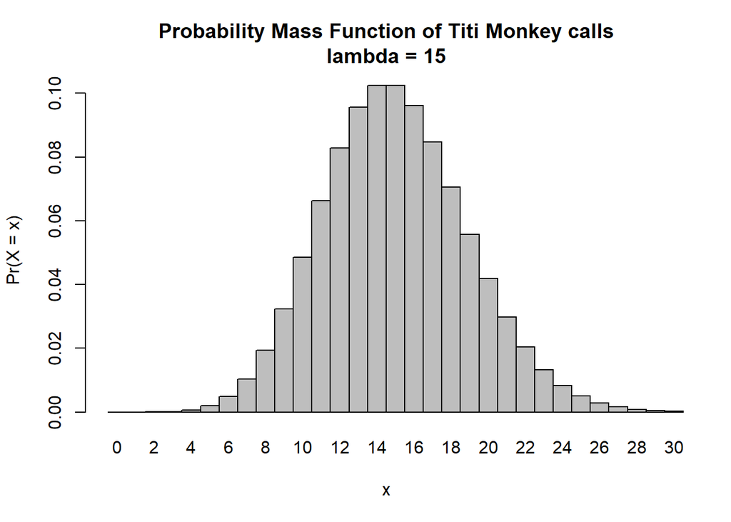

```r
x <- 0:30
l = 15
poistiti <- dpois(x = 0:30, lambda = 15)
barplot(poistiti, names.arg = x, space = 0, xlab = "x", ylab = "Pr(X = x)",
        main = paste0("Probability Mass Function of Titi Monkey calls\nlambda = ", l), xlim = c(0,30))
```

## 1.e. Simulate 104 results from this distribution (i.e., 2 years of Saturday monitoring sessions)

```r
rpois(n = 104, lambda = 15)
```

```
##   [1] 16 17 17 25 11 11 18 17 15  8 12 12 22 22 16 22 17 17 11 22 18 15 11
##  [24] 15 12 26 17 14 16 27 15 15 14 11 10 17 16 13 11 19 11 17 13 20 11 14
##  [47] 12 14 20 14 21 12  6 10 15 17 20 17 14 15 15 15 14 21 15 16 22 16 17
##  [70] 16  3 17 22 16 15 13 20 13 16 18 17 15 11 11 21 10 20 14 15 18 11  8
##  [93] 10 16 13 17 23 11 18 15 16 13 10 12
```

## 1.f. Plot the simulated results using hist() and use xlim() to set the horizontal limits to be from 0 to 30. How does your histogram compare to the shape of the probability mass function you plotted above?

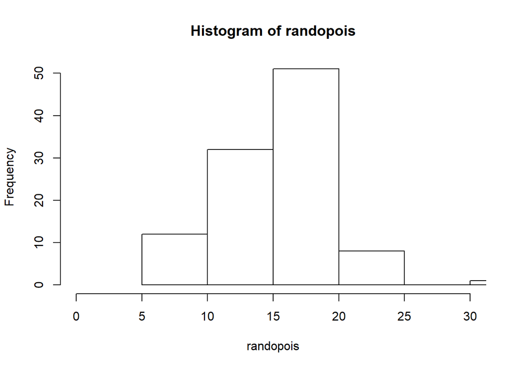

```r
randopois <- rpois(n = 104, lambda = 15)
hist(x = randopois, xlim = c(0,30))
```

# QUESTION 2: Load in the dataset “zombies.csv” from my GitHub repository at https://github.com/difiore/ADA-2019. This data includes the first and last name and gender of the entire population of 1000 people who have survived the zombie apocalypse and are now ekeing out an existence somewhere on the East Coast, along with several other variables (height, weight, age, number of years of education, number of zombies they have killed, and college major see here for info on important post-zombie apocalypse majors.

## Load in the zombies.csv dataset

```r
library(tidyverse)
library(curl)
```

```r
library(ggplot2)
library(dplyr)
f <- f <- curl("https://raw.githubusercontent.com/difiore/ADA-2019/master/zombies.csv")
d <- read.csv(f, header = TRUE, sep = ",", stringsAsFactors = FALSE)
head(d)
```

```
##   id first_name last_name gender   height   weight zombies_killed
## 1  1      Sarah    Little Female 62.88951 132.0872              2
## 2  2       Mark    Duncan   Male 67.80277 146.3753              5
## 3  3    Brandon     Perez   Male 72.12908 152.9370              1
## 4  4      Roger   Coleman   Male 66.78484 129.7418              5
## 5  5      Tammy    Powell Female 64.71832 132.4265              4
## 6  6    Anthony     Green   Male 71.24326 152.5246              1
##   years_of_education                           major      age
## 1                  1                medicine/nursing 17.64275
## 2                  3 criminal justice administration 22.58951
## 3                  1                       education 21.91276
## 4                  6                  energy studies 18.19058
## 5                  3                       logistics 21.10399
## 6                  4                  energy studies 21.48355
```

# 2.a. Calculate the population mean and standard deviation for each quantitative random variable (height, weight, age, number of zombies killed, and years of education).

## A function to calculate population variance

```r
popvar <- function(x) {
  sum((x - mean(x))^2)/(length(x))}
popvar(x)
```

```
## [1] 80
```

## A function to calculate population standard deviation

```r
popsd <- function(x) {
  sqrt(popvar(x))}
popsd(x)
```

```
## [1] 8.944272
```

## Calculate mean for each variable

```r
mean(d$height)
```

```
## [1] 67.6301
```

```r
mean(d$weight)
```

```
## [1] 143.9075
```

```r
mean(d$age)
```

```
## [1] 20.04696
```

```r
mean(d$zombies_killed)
```

```
## [1] 2.992
```

```r
mean(d$years_of_education)
```

```
## [1] 2.996
```

## Calculate SD for each variable

```r
popsd(d$height)
```

```
## [1] 4.30797
```

```r
popsd(d$weight)
```

```
## [1] 18.39186
```

```r
popsd(d$age)
```

```
## [1] 2.963583
```

```r
popsd(d$zombies_killed)
```

```
## [1] 1.747551
```

```r
popsd(d$years_of_education)
```

```
## [1] 1.675704
```

# 2.b. Use {ggplot} and make boxplots of each of these variable by gender.

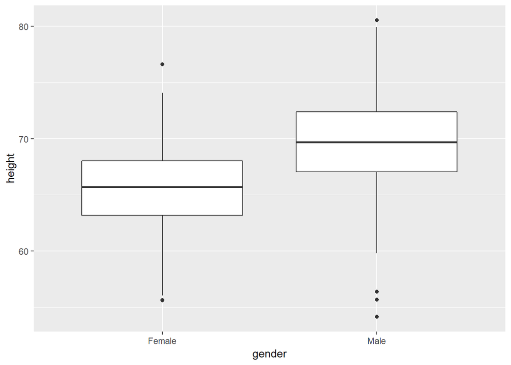

```r
library(ggplot2)
heightbox <- ggplot(d, aes(x = gender, y = height)) +
  geom_boxplot()
heightbox
```

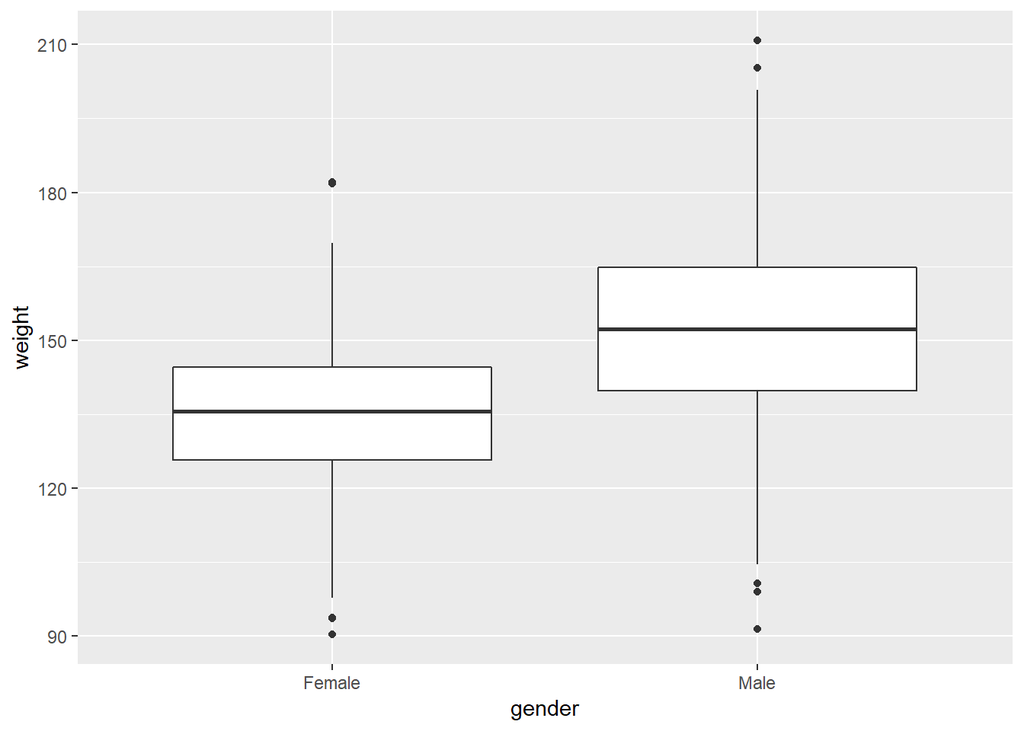

```r
weightbox <- ggplot(d, aes(x = gender, y = weight)) +
  geom_boxplot()
weightbox
```

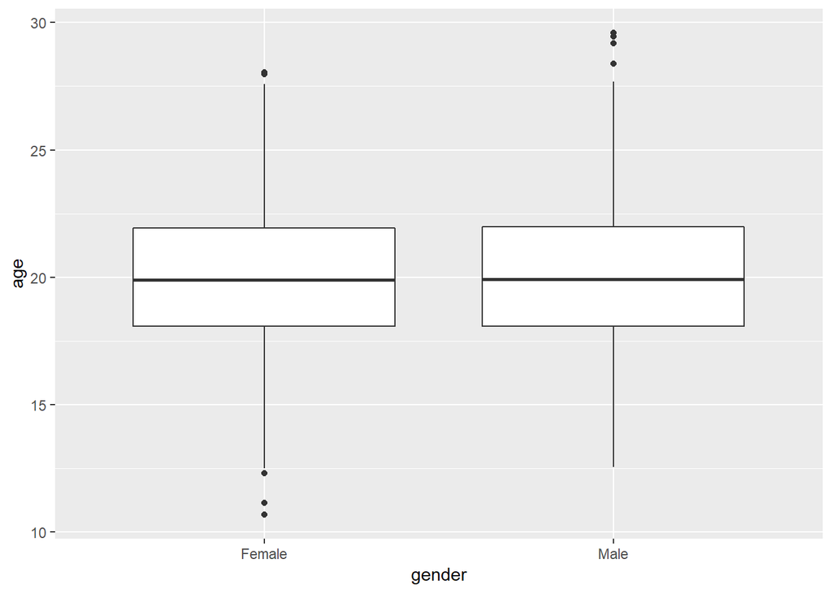

```r
agebox <- ggplot(d, aes( x = gender, y = age)) +
  geom_boxplot()
agebox
```

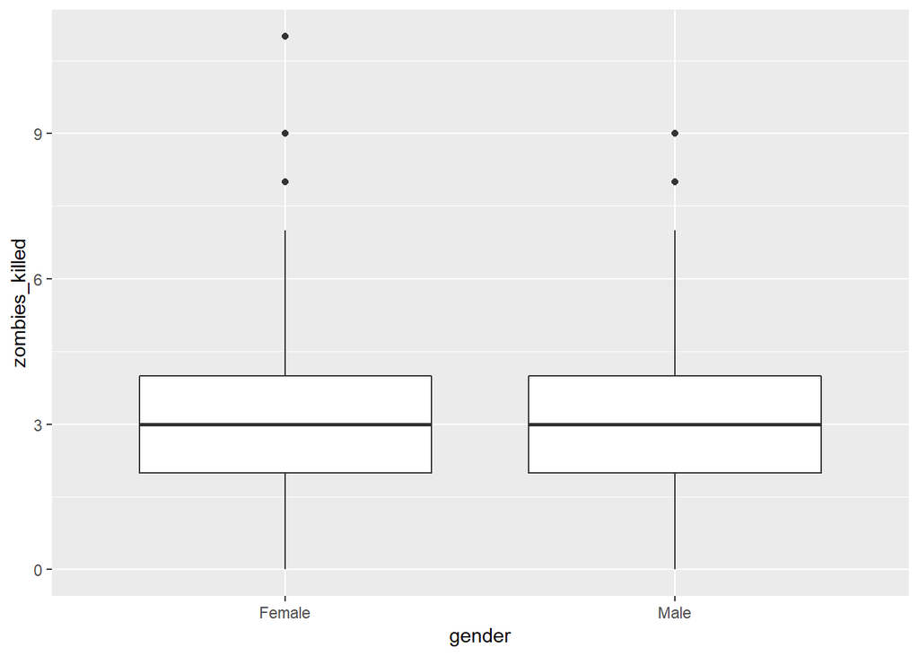

```r
zombieskilledbox <- ggplot(d, aes(x = gender, y = zombies_killed)) +
  geom_boxplot()
zombieskilledbox
```

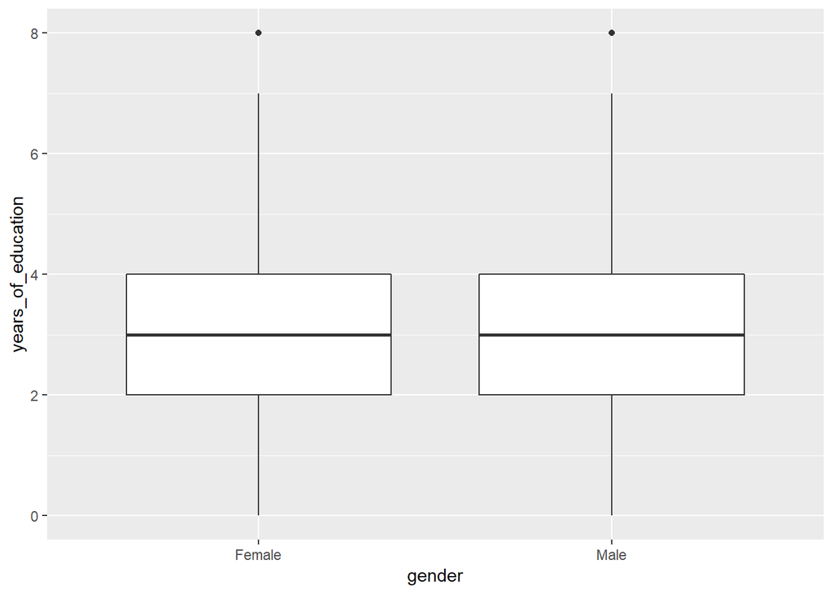

```r
yearsofeducationbox <- ggplot( d, aes(x = gender, y = years_of_education)) +
  geom_boxplot()
yearsofeducationbox
```

# 2.c. Use {ggplot} and make scatterplots of height and weight in relation to age. Do these variables seem to be related? In what way?

```r
heightfit = lm(d$height~d$age)
summary(heightfit)
```

```
##
## Call:
## lm(formula = d$height ~ d$age)
##
## Residuals:
##      Min       1Q   Median       3Q      Max
## -10.4838  -2.3500  -0.1779   2.4552   9.6580
##
## Coefficients:
##             Estimate Std. Error t value Pr(>|t|)
## (Intercept) 48.73566    0.70990   68.65   <2e-16 ***
## d$age        0.94251    0.03503   26.91   <2e-16 ***
## ---
## Signif. codes:  0 '***' 0.001 '**' 0.01 '*' 0.05 '.' 0.1 ' ' 1
##
## Residual standard error: 3.283 on 998 degrees of freedom
## Multiple R-squared:  0.4204, Adjusted R-squared:  0.4198
## F-statistic: 723.9 on 1 and 998 DF,  p-value: < 2.2e-16
```

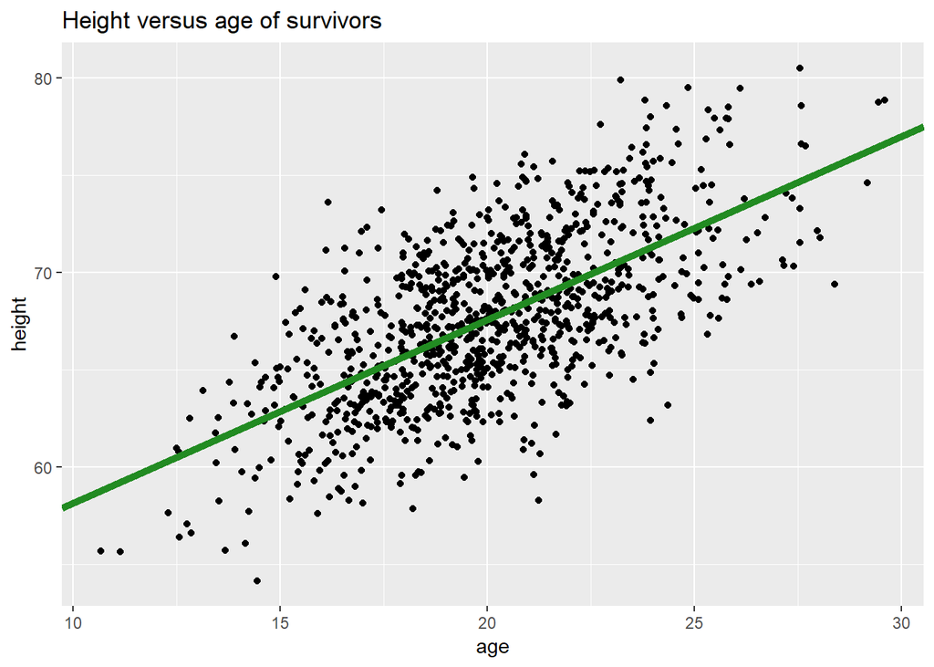

```r
heightscatter <- ggplot(d, aes(x= age, y= height)) + geom_point() +
  geom_abline(mapping = NULL, data = NULL, slope =  0.94251,
  intercept = 48.73566, size = 2, col= "forestgreen") + labs(title = "Height versus age of survivors")
heightscatter
```

## Height and age have somewhat a slightly negatively allometric relationship. Height increases at a relatively slower rate than age does.

```r
weightfit = lm(d$weight~d$age)
summary(weightfit)
```

```
##
## Call:
## lm(formula = d$weight ~ d$age)
##
## Residuals:
##     Min      1Q  Median      3Q     Max
## -56.000 -12.191  -0.902  11.272  60.558
##
## Coefficients:
##             Estimate Std. Error t value Pr(>|t|)
## (Intercept) 104.0563     3.7712   27.59   <2e-16 ***
## d$age         1.9879     0.1861   10.68   <2e-16 ***
## ---
## Signif. codes:  0 '***' 0.001 '**' 0.01 '*' 0.05 '.' 0.1 ' ' 1
##
## Residual standard error: 17.44 on 998 degrees of freedom
## Multiple R-squared:  0.1026, Adjusted R-squared:  0.1017
## F-statistic: 114.1 on 1 and 998 DF,  p-value: < 2.2e-16
```

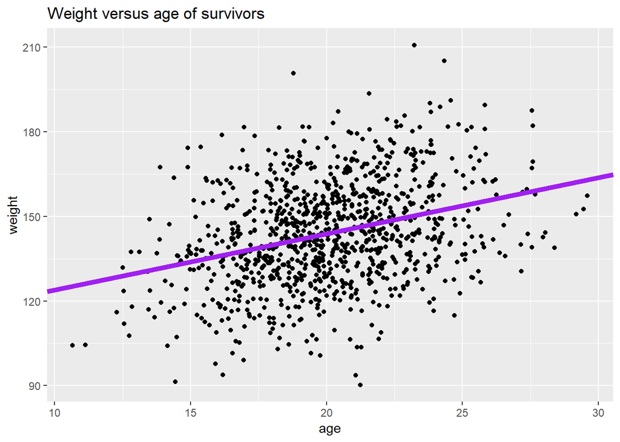

```r
weightscatter <- ggplot(d, aes(x= age, y= weight)) + geom_point() +
  geom_abline(mapping = NULL, data = NULL, slope =  1.9879,
  intercept = 104.0563, size = 2, col= "purple") + labs(title = "Weight versus age of survivors")
weightscatter
```

# 2.d. Using histograms and Q-Q plots, check whether the quantitative variables seem to be drawn from a normal distribution. Which seem to be and which do not? For those that are not, can you determine what common distribution they are drawn from?

## Height

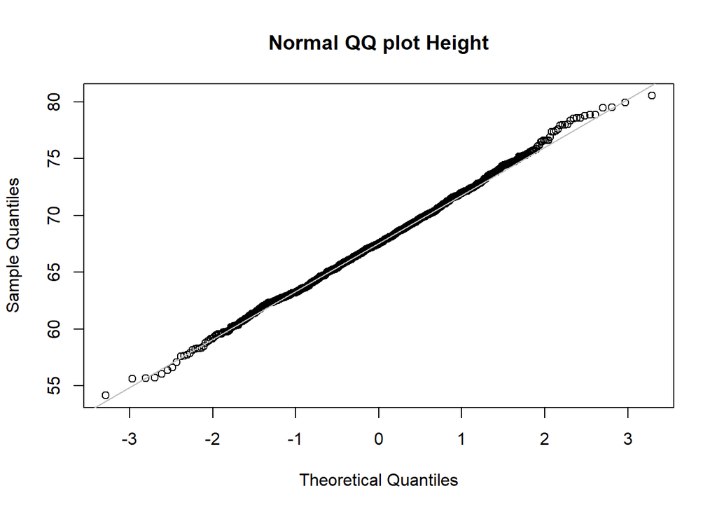

```r
qqnorm(d$height, main = "Normal QQ plot Height")
qqline(d$height, col = "gray")
```

### Height does have a normal distribution

## Weight

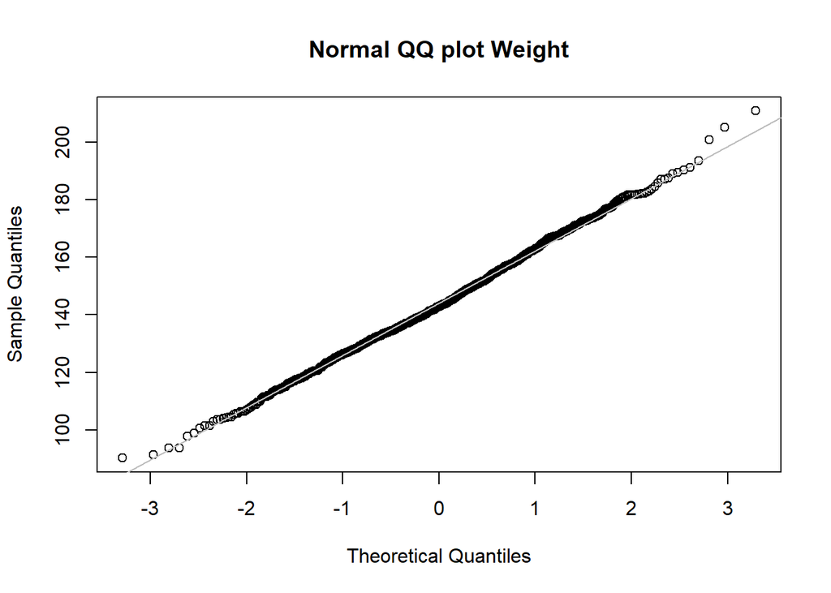

```r
qqnorm(d$weight, main = "Normal QQ plot Weight")
qqline(d$weight, col = "gray")
```

### Weight does a normal distribution

## Age

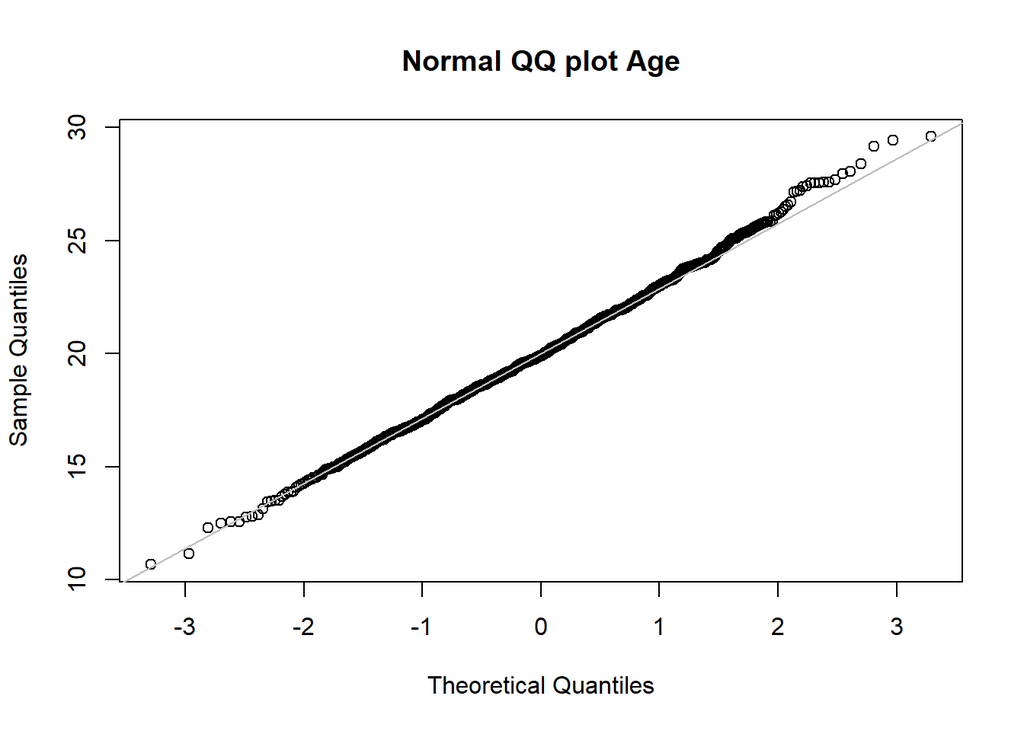

```r
qqnorm(d$age, main = "Normal QQ plot Age")
qqline(d$age, col = "gray")
```

[figure not shown]

```r
hist(d$zombies_killed)
```

## Zombies killed

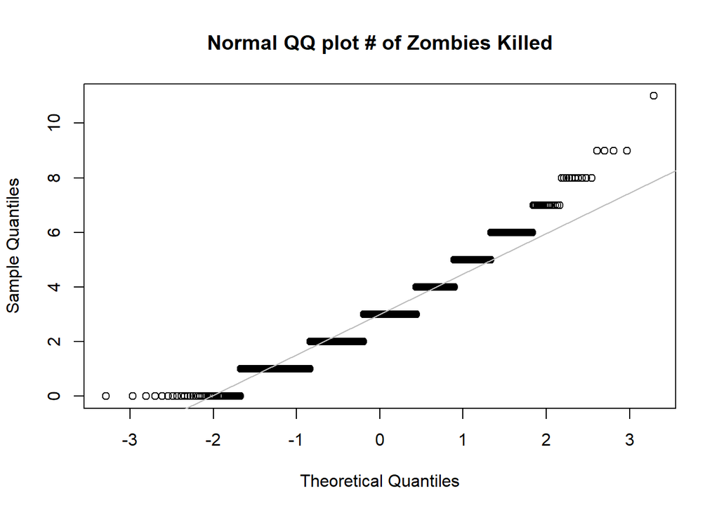

```r
qqnorm(d$zombies_killed, main = "Normal QQ plot # of Zombies Killed")
qqline(d$zombies_killed, col = "gray")
```

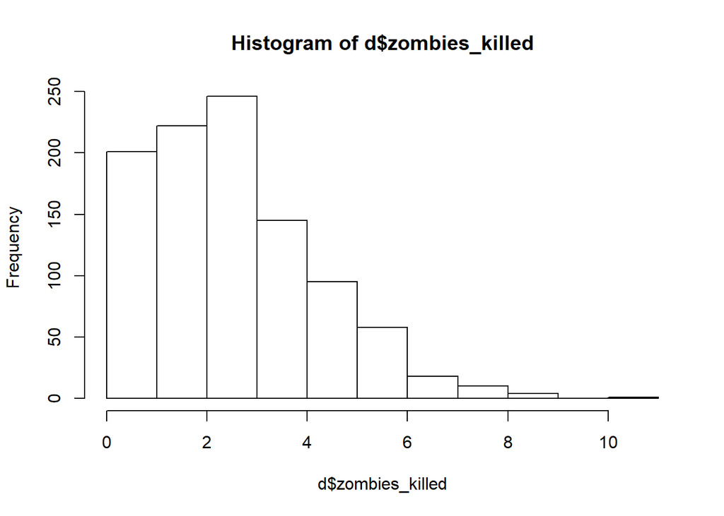

```r
hist(d$zombies_killed)
```

### The Number of zombies killed appears to be a poisson distribution

## Years of Education

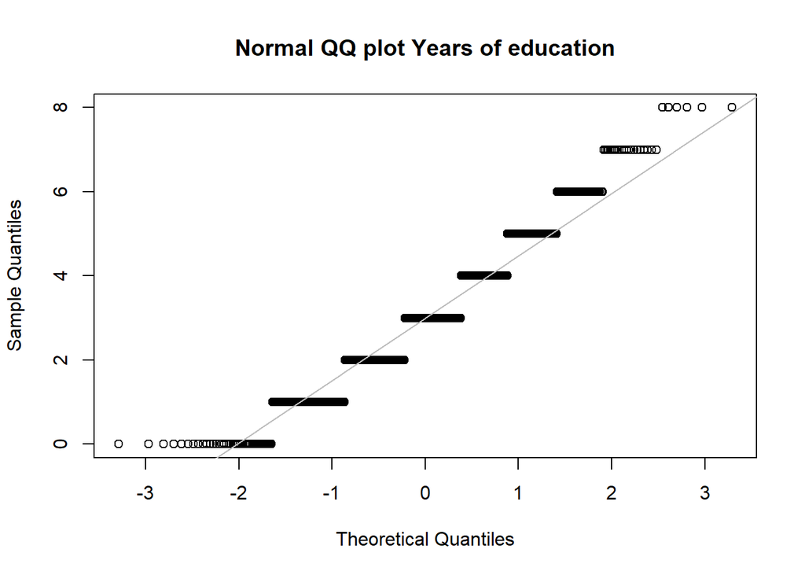

```r
qqnorm(d$years_of_education, main = "Normal QQ plot Years of education")
qqline(d$years_of_education, col = "gray")
```

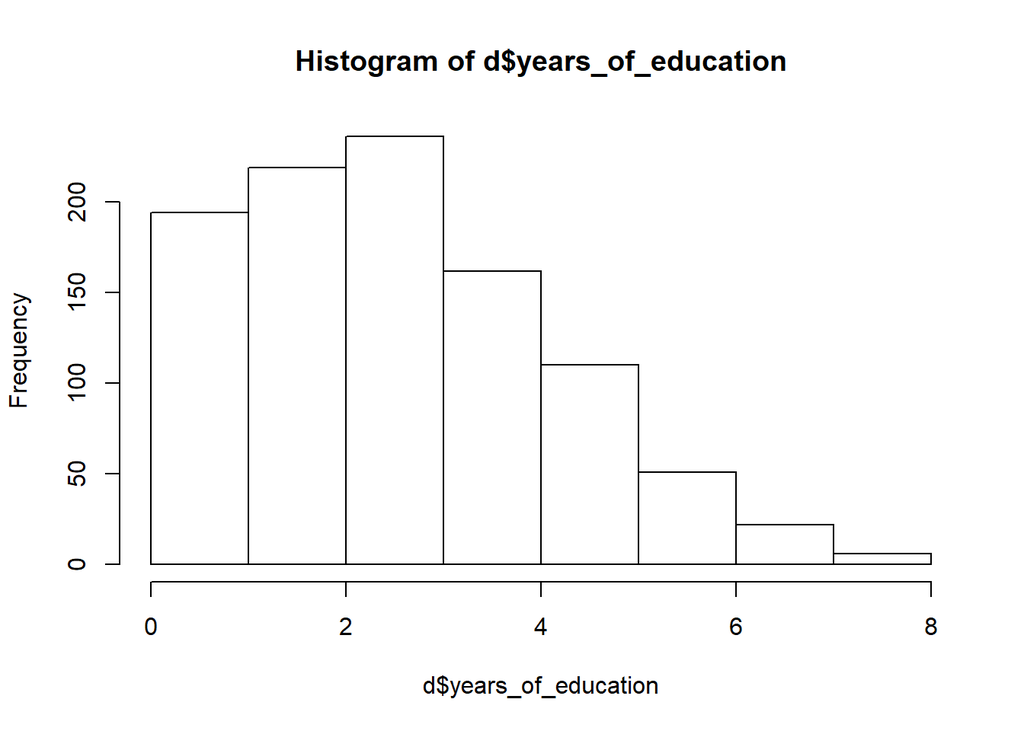

```r
hist(d$years_of_education)
```

# 2.e. Now use the sample() function to sample ONE subset of 30 zombies (without replacement) from this population and calculate the mean and sample standard deviation for each variable. Also, # estimate the standard error for each variable and construct the 95% confidence interval for each mean. Note that for the variables that are not drawn from the normal distribution, you will need to base your estimate of the CIs on some different distribution!

## First sample the population

```r
dsample <- d[sample(1:1000, 30, replace=FALSE), ]
head(dsample)
```

```
##      id first_name last_name gender   height   weight zombies_killed
## 323 323    Raymond     Price   Male 71.48824 153.9499              1
## 987 987     Joseph  Anderson   Male 71.62507 157.0922              4
## 765 765    Carolyn    Tucker Female 58.35161 114.9680              3
## 156 156       John     Young   Male 72.69807 140.6522              1
## 203 203      Kelly Hernandez Female 67.77072 151.7219              2
## 321 321       Joan   Andrews Female 55.66449 104.3203              3
##     years_of_education              major      age
## 323                  3       pharmacology 19.67347
## 987                  5 physical education 20.40505
## 765                  2      city planning 15.23501
## 156                  2   applied sciences 24.56925
## 203                  2   medicine/nursing 21.22370
## 321                  2       architecture 10.66381
```

## Calculate mean for each variable

```r
mean(dsample$height)
```

```
## [1] 67.91485
```

```r
mean(dsample$weight)
```

```
## [1] 145.0234
```

```r
mean(dsample$age)
```

```
## [1] 19.68095
```

```r
mean(dsample$zombies_killed)
```

```
## [1] 2.6
```

```r
mean(dsample$years_of_education)
```

```
## [1] 3.066667
```

## Calcualte Standard Deviation for each variable

```r
sd(dsample$height)
```

```
## [1] 4.676517
```

```r
sd(dsample$weight)
```

```
## [1] 17.69293
```

```r
sd(dsample$age)
```

```
## [1] 3.126368
```

```r
sd(dsample$zombies_killed)
```

```
## [1] 1.631585
```

```r
sd(dsample$years_of_education)
```

```
## [1] 1.595972
```

### Create function to estimate Standard Error

```r
se <- function(x) {
  sd(x)/sqrt(length(x))
}
```

## Estimate Standard error for each variable

```r
se(dsample$height)
```

```
## [1] 0.8538113
```

```r
se(dsample$weight)
```

```
## [1] 3.230273
```

```r
se(dsample$age)
```

```
## [1] 0.570794
```

```r
se(dsample$zombies_killed)
```

```
## [1] 0.2978853
```

```r
se(dsample$years_of_education)
```

```
## [1] 0.2913833
```

## Construct 95% confidence intervals for each variable

### HEIGHT

```r
upperheight <- mean(dsample$height) + qnorm(0.975) * se(dsample$height)
lowerheight <- mean(dsample$height) - qnorm(0.975) * se(dsample$height)
ciheight <- c(lowerheight, upperheight)
ciheight
```

```
## [1] 66.24141 69.58829
```

### WEIGHT

```r
upperweight <- mean(dsample$weight) + qnorm(0.975) * se(dsample$weight)
lowerweight <- mean(dsample$weight) - qnorm(0.975) * se(dsample$weight)
ciweight <- c(lowerweight, upperweight)
ciweight
```

```
## [1] 138.6922 151.3546
```

## AGE

```r
upperage <- mean(dsample$age) + qpois(0.975, lambda = mean(dsample$age)) * se(dsample$age)
lowerage <- mean(dsample$age) - qpois(0.975, lambda = mean(dsample$age)) * se(dsample$age)
ciage <- c(lowerage, upperage)
ciage
```

```
## [1]  3.127919 36.233973
```

## ZOMBIES KILLED

```r
upperzombies <- mean(dsample$zombies_killed) + qpois(0.975,
      lambda = mean(dsample$zombies_killed)) * se(dsample$zombies_killed)
lowerzombies <- mean(dsample$zombies_killed) - qpois(0.975,
      lambda = mean(dsample$zombies_killed)) * se(dsample$zombies_killed)
cizombies <- c(lowerzombies, upperzombies)
cizombies
```

```
## [1] 0.8126884 4.3873116
```

## YEARS OF EDCUCATION

```r
upperyears_of_education <- mean(dsample$years_of_education) + qpois(0.975,
      lambda = mean(dsample$years_of_education)) * se(dsample$years_of_education)
loweryears_of_education <- mean(dsample$years_of_education) - qpois(0.975,
      lambda = mean(dsample$years_of_education)) * se(dsample$years_of_education)
cieducation <- c(loweryears_of_education, upperyears_of_education)
cieducation
```

```
## [1] 1.026984 5.106350
```

# 2.f. Now draw 99 more random samples of 30 zombies out and calculate the mean for each of the these samples. Together with the first sample you drew out, you now have a set of 100 means for each variable (each based on 30 observations), which constitutes a sampling distribution for each variable. What are the means and standard deviations of the sampling distribution for each variable? How do the standard deviations compare to the standard errors estimated in [2.e.]? What do these sampling distributions look like? Are they normally distributed? What about for those variables that you concluded were not originally drawn from a normal distribution?

## Sample each variable of interest in 99 iterations of 30 samples each from the original dataset

```r
k <- 99
n <- 30
dsample2 <- NULL
dsamplemeanheight <- NULL
dsampleSDheight <- NULL
dsampleSEheight <- NULL
dsamplemeanweight <- NULL
dsampleSDweight <- NULL
dsampleSEweight <- NULL
dsamplemeanage <- NULL
dsampleSDage <- NULL
dsampleSEage <- NULL
dsamplemeanzombies <- NULL
dsampleSDzombies <- NULL
dsampleSEzombies <- NULL
dsamplemeaneducation <- NULL
dsampleSDeducation <- NULL
dsampleSEeducation <- NULL
 for (i in 1:99) {
   dsample2 <- sample_n(d, size = n, replace = FALSE)
   dsamplemeanheight[i] <- mean(dsample2$height)
   dsampleSDheight[i] <- sd(dsample2$height)
   dsampleSEheight[i] <- se(dsample2$height)
   dsamplemeanweight[i] <- mean(dsample2$weight)
   dsampleSDweight[i] <- sd(dsample2$weight)
   dsampleSEweight[i] <- se(dsample2$weight)
   dsamplemeanage[i] <- mean(dsample2$age)
   dsampleSDage[i] <- sd(dsample2$age)
   dsampleSEage[i] <- se(dsample2$age)
   dsamplemeanzombies[i] <- mean(dsample2$zombies_killed)
   dsampleSDzombies[i] <- sd(dsample2$zombies_killed)
   dsampleSEzombies[i] <- se(dsample2$zombies_killed)
   dsamplemeaneducation[i] <- mean(dsample2$years_of_education)
   dsampleSDeducation[i] <- sd(dsample2$years_of_education)
   dsampleSEeducation[i] <- se(dsample2$years_of_education)
   }
```

## Create a data frame with means for each of the variables across all of the 99 new samples

```r
sampledistmeanheight <- as.data.frame(dsamplemeanheight)
sampledistSDheight <- as.data.frame(dsampleSDheight)
sampledistSEheight <- as.data.frame(dsampleSEheight)
sampledistmeanweight <- as.data.frame(dsamplemeanweight)
sampledistSDweight <- as.data.frame(dsampleSDweight)
sampledistSEweight <- as.data.frame(dsampleSEweight)
sampledistmeanage <- as.data.frame(dsamplemeanage)
sampledistSDage <- as.data.frame(dsampleSDage)
sampledistSEage <- as.data.frame(dsampleSEage)
sampledistmeanzombies <- as.data.frame(dsamplemeanzombies)
sampledistSDzombies <- as.data.frame(dsampleSDzombies)
sampledistSEzombies <- as.data.frame(dsampleSEzombies)
sampledistmeaneducation <- as.data.frame(dsamplemeaneducation)
sampledistSDeducation <- as.data.frame(dsampleSDeducation)
sampledistSEeducation <- as.data.frame(dsampleSEeducation)
```

## Combine the means from each sample into a single data frame

```r
sampledist <- cbind(sampledistmeanheight, sampledistSDheight, sampledistSEheight,
      sampledistmeanweight, sampledistSDweight, sampledistSEweight,
      sampledistmeanage, sampledistSDage, sampledistSEage,
      sampledistmeanzombies, sampledistSDzombies, sampledistSEzombies,
      sampledistmeaneducation, sampledistSDeducation, sampledistSEeducation)
```

## Take the means of the original sample vector (from 2.e) and add to the sample distribution. This is the sample distribution of all 100 samples

```r
dsamplemeans <- c(mean(dsample$height), sd(dsample$height), se(dsample$height),
                  mean(dsample$weight), sd(dsample$weight), se(dsample$weight),
                  mean(dsample$age), sd(dsample$age), se(dsample$age),
                  mean(dsample$zombies_killed), sd(dsample$zombies_killed), se(dsample$zombies_killed),
                  mean(dsample$years_of_education), sd(dsample$years_of_education), se(dsample$years_of_education))
sampledist <- rbind(sampledist, dsamplemeans)
```

## Determine the mean of means, mean of SD’s, and mean of SE’s of the sample distribution

### Mean of Means for each variable

```r
mean(sampledist$dsamplemeanheight)
```

```
## [1] 67.67343
```

```r
mean(sampledist$dsamplemeanweight)
```

```
## [1] 144.0957
```

```r
mean(sampledist$dsamplemeanage)
```

```
## [1] 20.08328
```

```r
mean(sampledist$dsamplemeanzombies)
```

```
## [1] 2.970667
```

```r
mean(sampledist$dsamplemeaneducation)
```

```
## [1] 2.989333
```

```r
sd(sampledist$dsampleSDheight)
```

```
## [1] 0.5515632
```

```r
sd(sampledist$dsampleSDweight)
```

```
## [1] 2.538789
```

```r
sd(sampledist$dsampleSDage)
```

```
## [1] 0.421796
```

```r
sd(sampledist$dsampleSDzombies)
```

```
## [1] 0.2481991
```

```r
sd(sampledist$dsampleSDeducation)
```

```
## [1] 0.1853236
```

```r
se(sampledist$dsampleSEheight)
```

```
## [1] 0.01007012
```

```r
se(sampledist$dsampleSEweight)
```

```
## [1] 0.04635174
```

```r
se(sampledist$dsampleSEage)
```

```
## [1] 0.007700906
```

```r
se(sampledist$dsampleSEzombies)
```

```
## [1] 0.004531474
```

```r
se(sampledist$dsampleSEeducation)
```

```
## [1] 0.003383531
```

## How do the sampling distribution SD’s compare to the SE’s from 2e

```r
se(dsample$height)
```

```
## [1] 0.8538113
```

```r
sd(sampledist$dsampleSDheight)
```

```
## [1] 0.5515632
```

```r
se(dsample$weight)
```

```
## [1] 3.230273
```

```r
sd(sampledist$dsampleSDweight)
```

```
## [1] 2.538789
```

```r
se(dsample$age)
```

```
## [1] 0.570794
```

```r
sd(sampledist$dsampleSDage)
```

```
## [1] 0.421796
```

```r
se(dsample$zombies_killed)
```

```
## [1] 0.2978853
```

```r
sd(sampledist$dsampleSDzombies)
```

```
## [1] 0.2481991
```

```r
se(dsample$years_of_education)
```

```
## [1] 0.2913833
```

```r
sd(sampledist$dsampleSDeducation)
```

```
## [1] 0.1853236
```

### In all cases the SE’s from 2.e. are slightly higher than the SD’s of the sampling distribution

## What do these sampling distributions look like? Are they normally distributed? What about for those variables that you concluded were not originally drawn from a normal distribution?

### Create Histograms and QQ plots of each variable

### Mean Height

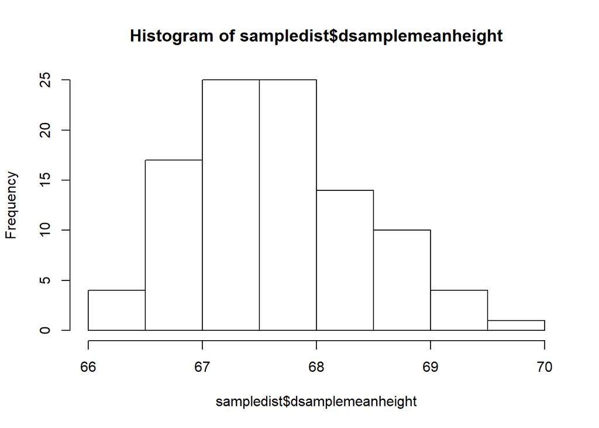

```r
hist(sampledist$dsamplemeanheight)
```

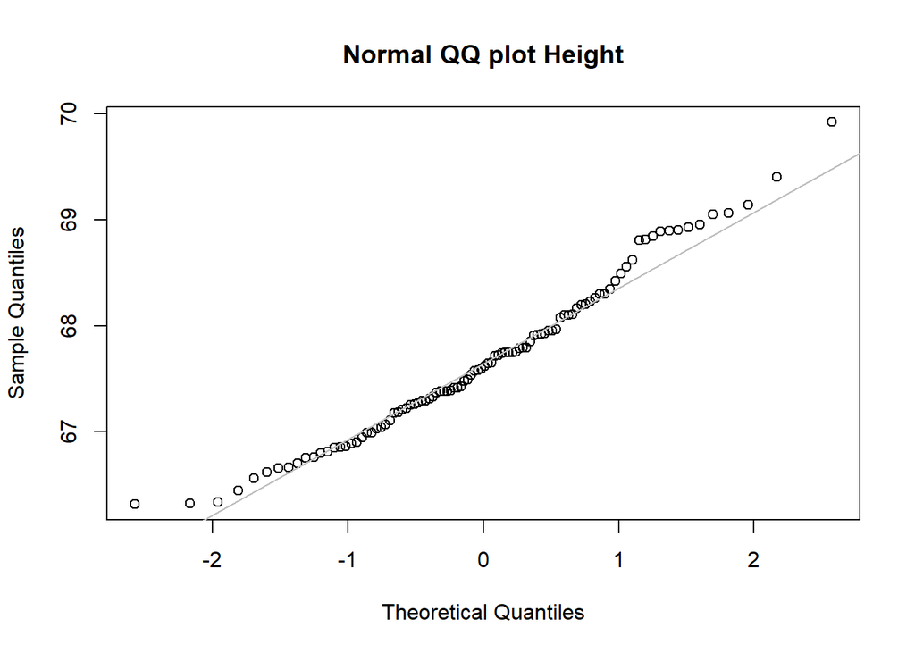

```r
qqnorm(sampledist$dsamplemeanheight, main = "Normal QQ plot Height")
qqline(sampledist$dsamplemeanheight, col = "gray")
```

#### Mean height is normally distributed

### Mean Weight

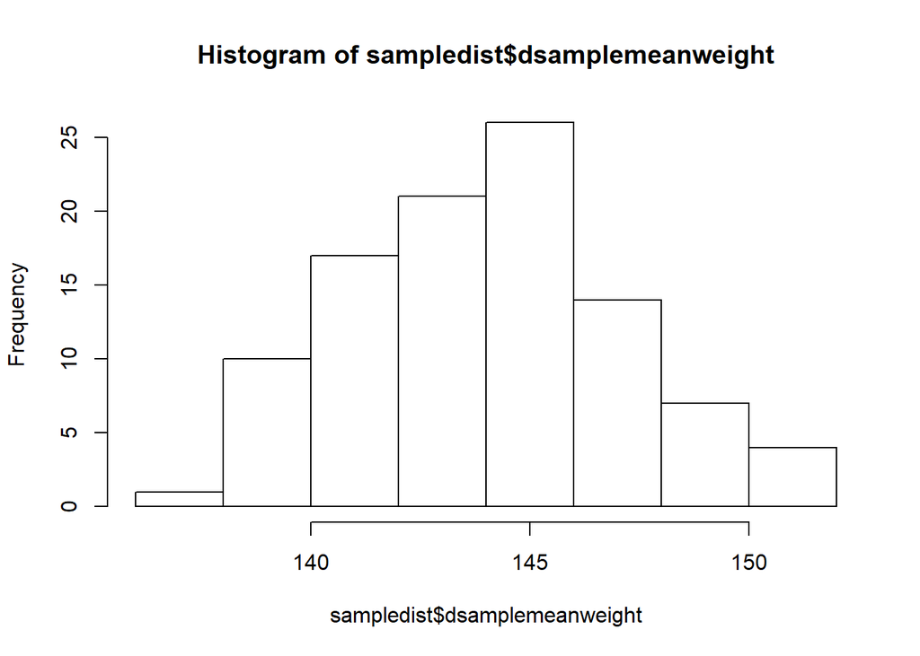

```r
hist(sampledist$dsamplemeanweight)
```

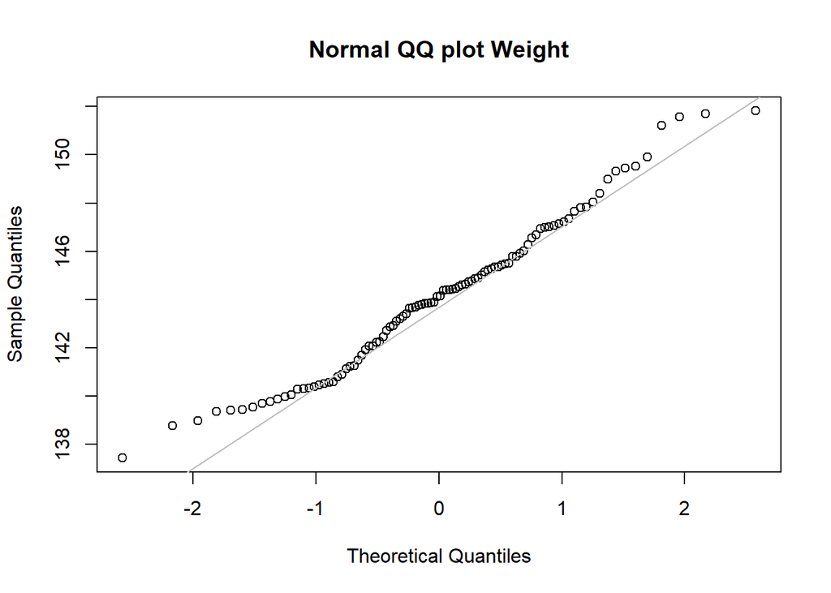

```r
qqnorm(sampledist$dsamplemeanweight, main = "Normal QQ plot Weight")
qqline(sampledist$dsamplemeanweight, col = "gray")
```

### Mean Age

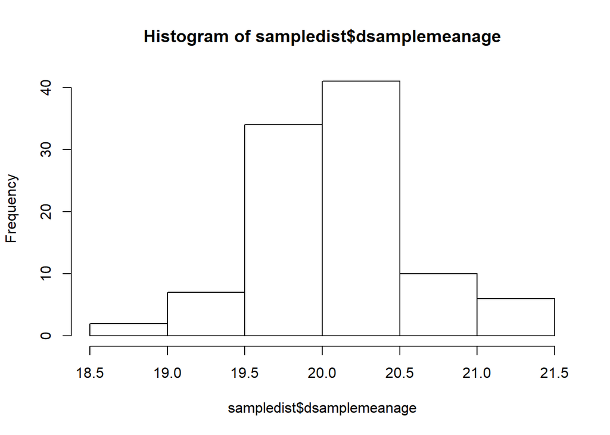

```r
hist(sampledist$dsamplemeanage)
```

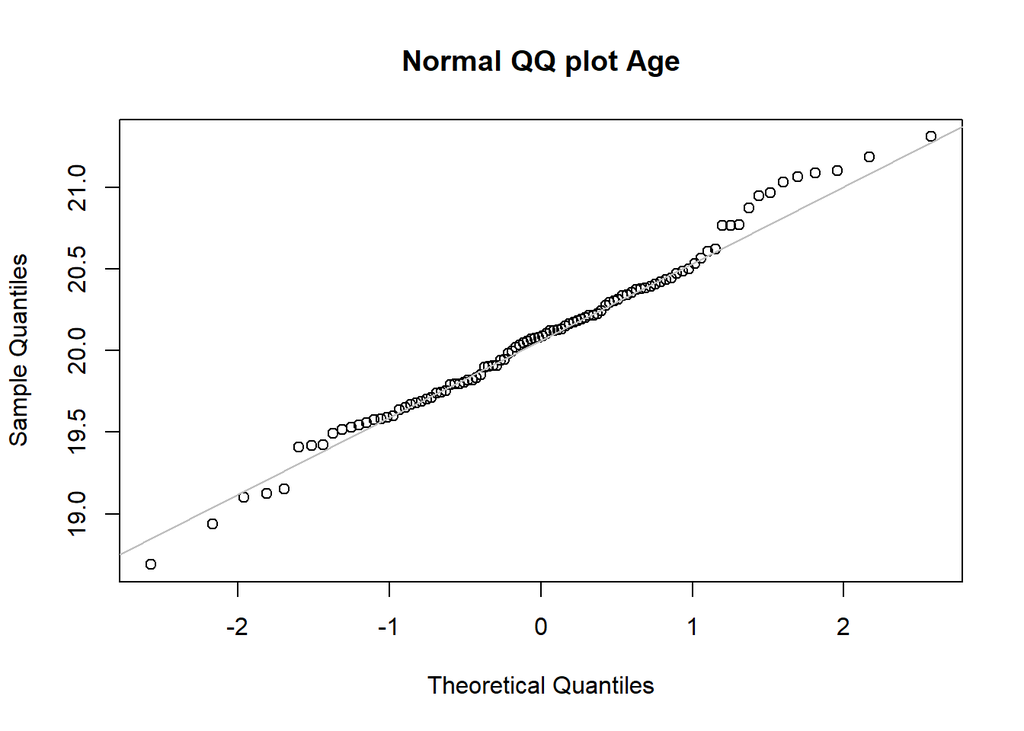

```r
qqnorm(sampledist$dsamplemeanage, main = "Normal QQ plot Age")
qqline(sampledist$dsamplemeanage, col = "gray")
```

### Mean Zombies Killed

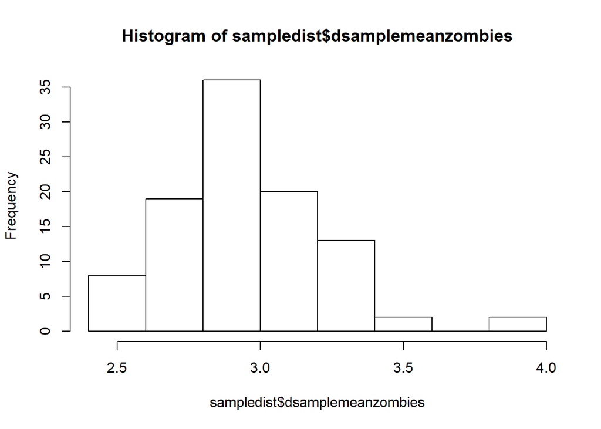

```r
hist(sampledist$dsamplemeanzombies)
```

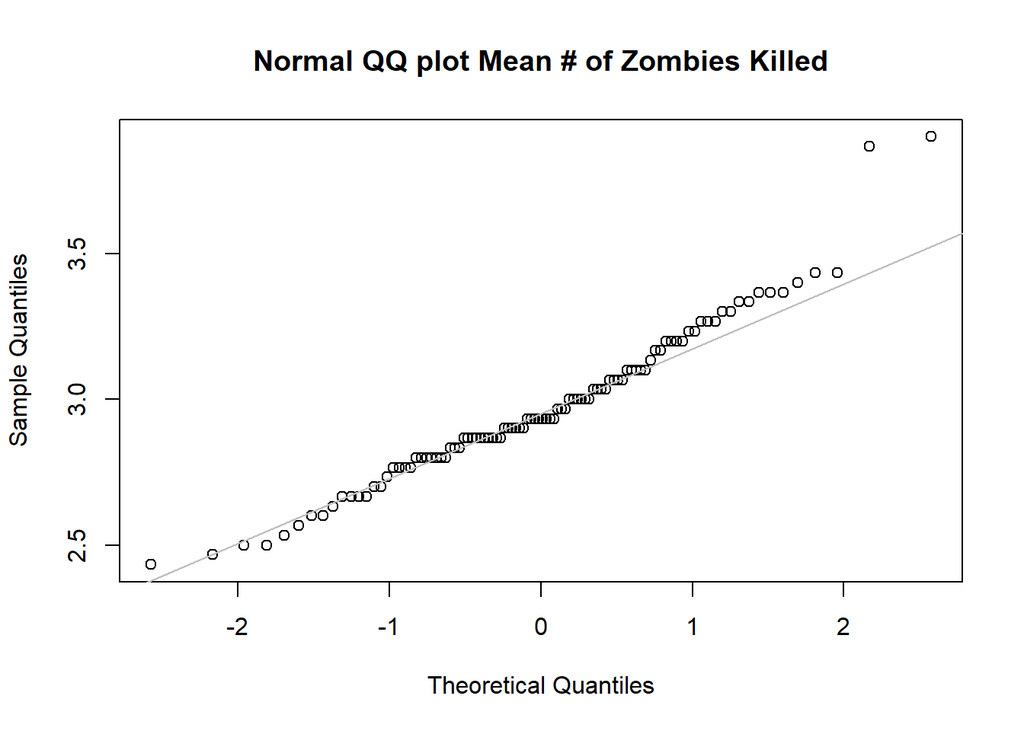

```r
qqnorm(sampledist$dsamplemeanzombies, main = "Normal QQ plot Mean # of Zombies Killed")
qqline(sampledist$dsamplemeanzombies, col = "gray")
```

### Mean Years of Education

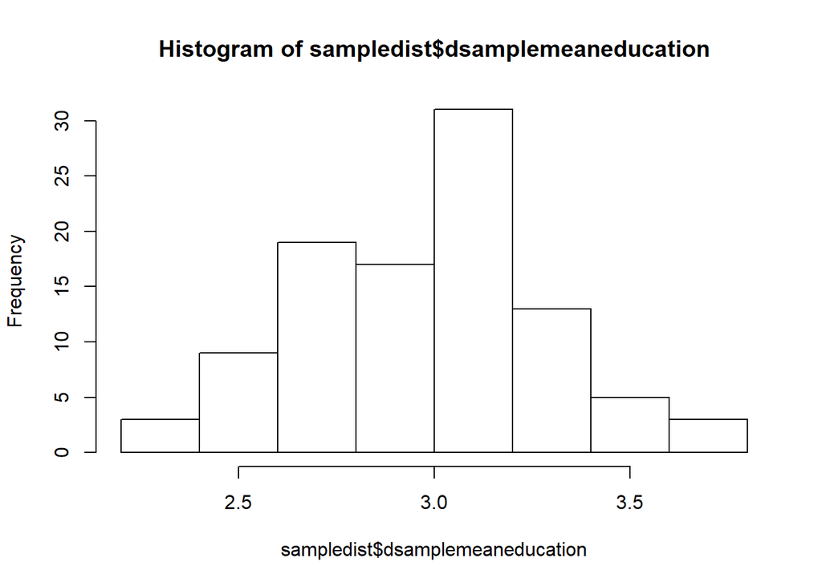

```r
hist(sampledist$dsamplemeaneducation)
```

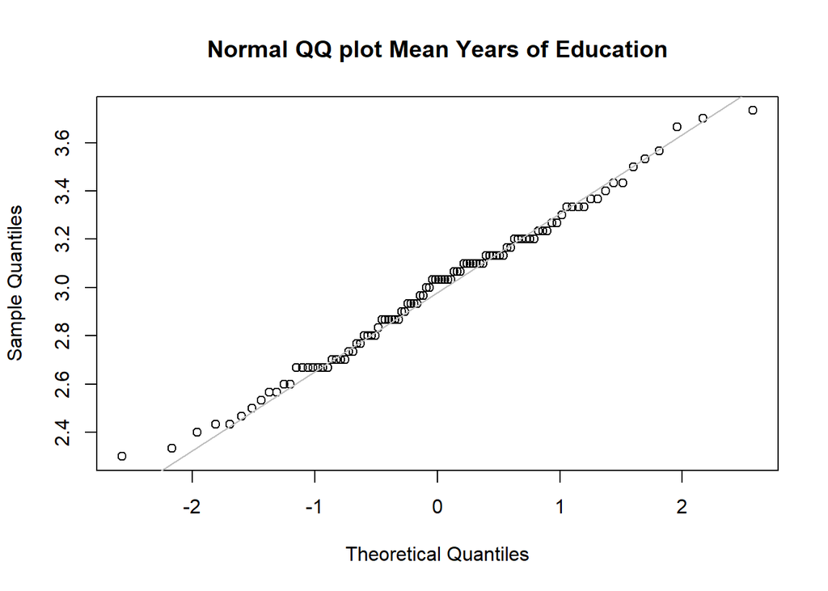

```r
qqnorm(sampledist$dsamplemeaneducation, main = "Normal QQ plot Mean Years of Education")
qqline(sampledist$dsamplemeaneducation, col = "gray")
```

### SD Height

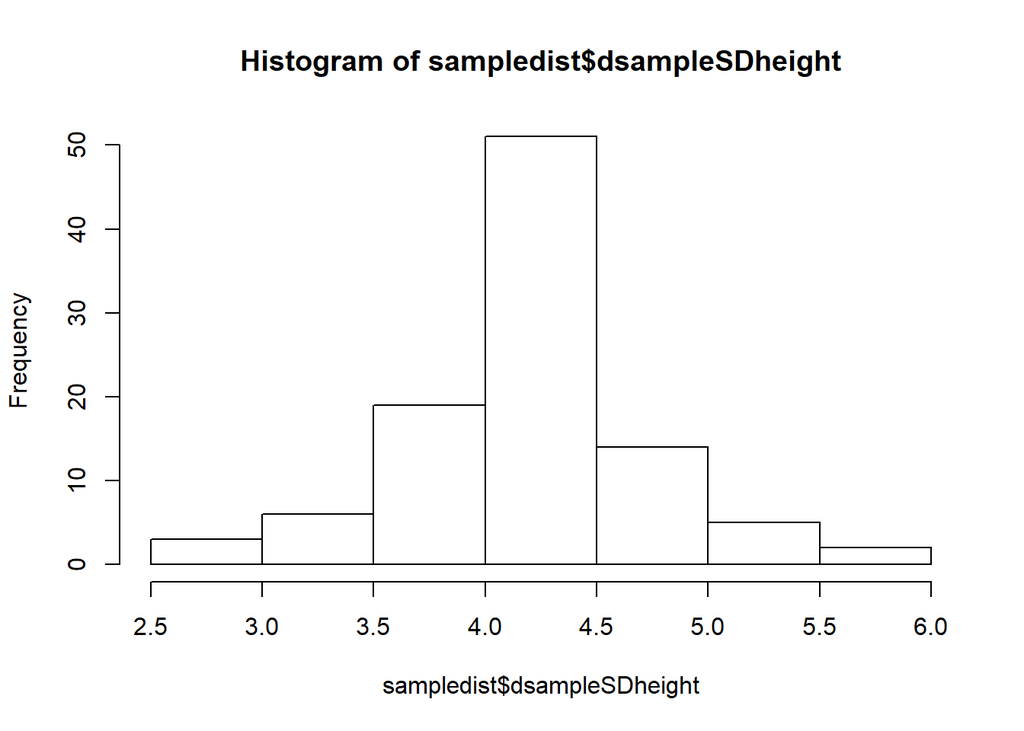

```r
hist(sampledist$dsampleSDheight)
```

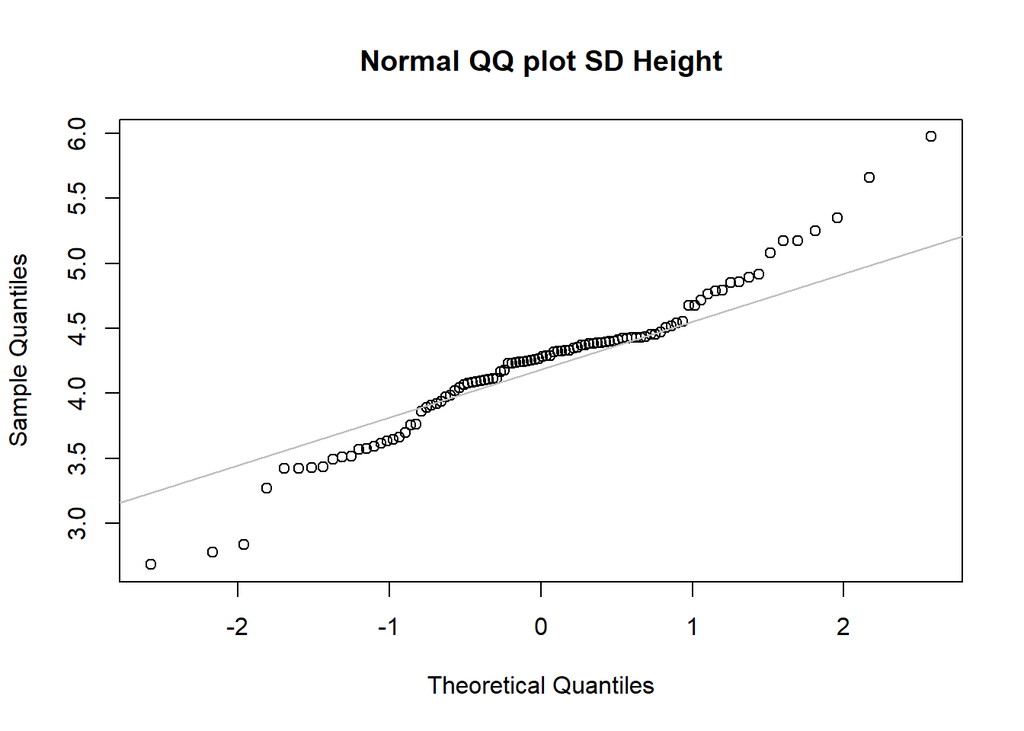

```r
qqnorm(sampledist$dsampleSDheight, main = "Normal QQ plot SD Height")
qqline(sampledist$dsampleSDheight, col = "gray")
```

#### SD height is not normally distributed

### SD Weight

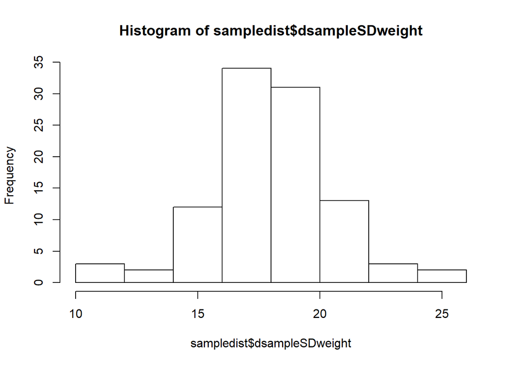

```r
hist(sampledist$dsampleSDweight)
```

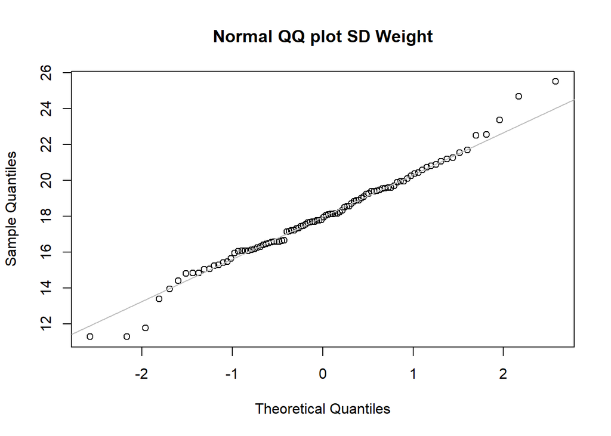

```r
qqnorm(sampledist$dsampleSDweight, main = "Normal QQ plot SD Weight")
qqline(sampledist$dsampleSDweight, col = "gray")
```